# Stat 208 - Linear Models - HW 1

Jordan Berninger

4/8/2020

## Question 1

We simply read in the data and fit a linear model using $lm()$ with an intercept term. We see the fitted parameters in the estimate column of the model summary.

```r
snow <- data.frame(city = c("Denver", "Boulder", "Estes Park", "Breckenridge", "Steamboat Springs", "Aspen"),
                   elevation = c(5.280, 5.328, 7.522, 9.600, 6.743, 7.406),
                   avg_snow = c(64, 70, 90, 225, 180, 175))

m <- lm(data = snow, avg_snow ~ elevation)
summary(m)
```

```
##
## Call:
## lm(formula = avg_snow ~ elevation, data = snow)
##
## Residuals:
##       1       2       3       4       5       6
## -11.767  -7.412 -62.574   1.239  54.113  26.400
##
## Coefficients:
##             Estimate Std. Error t value Pr(>|t|)
## (Intercept)  -105.11      86.96  -1.209   0.2933
## elevation      34.26      12.19   2.810   0.0483 *
## ---
## Signif. codes:  0 '***' 0.001 '**' 0.01 '*' 0.05 '.' 0.1 ' ' 1
##
## Residual standard error: 43.98 on 4 degrees of freedom
## Multiple R-squared:  0.6638, Adjusted R-squared:  0.5798
## F-statistic: 7.898 on 1 and 4 DF,  p-value: 0.0483
```

We note that the model summary shows a relatively high p-value for the intercept parameter ($\mu$ in the model notation), indicating a linear model through the origin may be more appropriate. We also plot the data and our fitted linear model and note this model fits the extreme data points well, the middle data points, not so well.

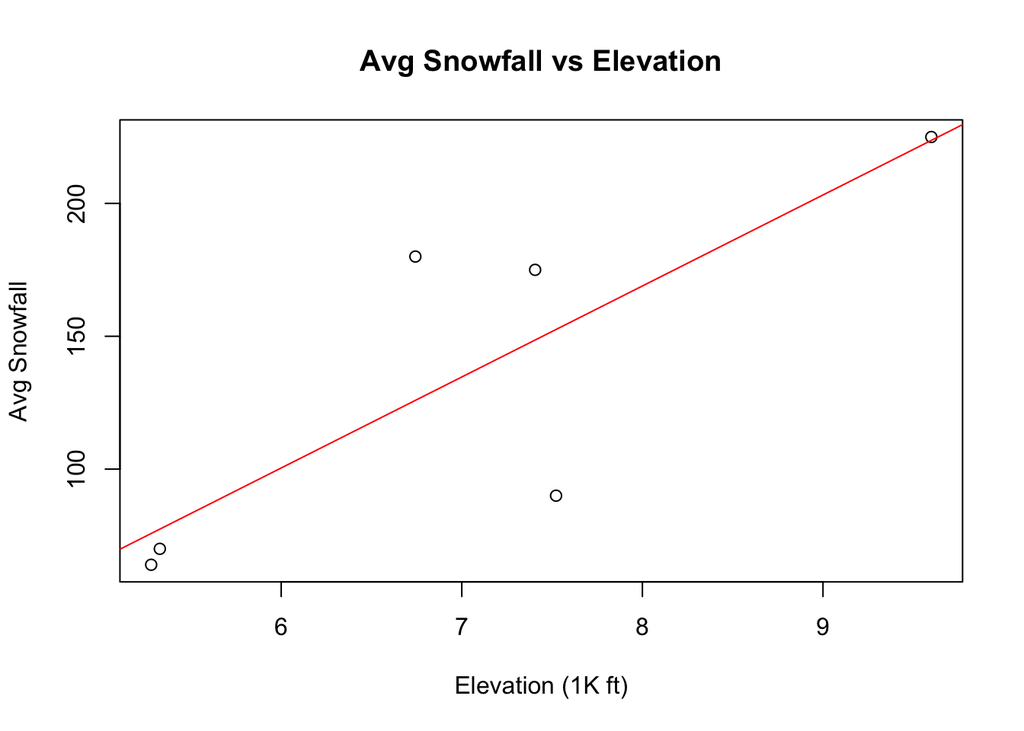

```r
plot(x = snow$elevation, y = snow$avg_snow, main = "Avg Snowfall vs Elevation",
     xlab = "Elevation (1K ft)", ylab = "Avg Snowfall")
abline(a = m$coefficients[1], b = m$coefficients[2], col = "red")
```

To get the model coefficients manually, we can use the projection matrix from the class notes: $\hat{\beta} = (X^TX)^{-1}X^TY$, which gives us the same values as $lm()$.

```r
x.mat <- matrix(c(rep(1,nrow(snow)), snow[,2]), ncol = 2, nrow = 6)
y.mat <- as.matrix(snow[,3])

beta.hat <- solve(t(x.mat) %*% x.mat)%*%t(x.mat)%*%y.mat
beta.hat
```

```
##            [,1]
## [1,] -105.11466
## [2,]   34.25793
```

## Question 2

$$\begin{aligned}
Var(\hat{\alpha}) &= Var\Bigg(\frac{\sum^n_{i=1}(x_i - \bar{x})y_i}{\sum^n_{i=1}(x_i - \bar{x})^2}\Bigg) \\
&= Var\Bigg(\frac{\sum^n_{i=1}(x_i - \bar{x})y_i}{S_{xx}}\Bigg) \\
&= S_{xx}^{-2}Var\Big(\sum^n_{i=1}(x_i - \bar{x})y_i\Big) \\
&= S_{xx}^{-2}Var\Big(\sum^n_{i=1}(x_i - \bar{x})y_i)\Big) \\
&= S_{xx}^{-2}\sum^n_{i=1}(x_i - \bar{x})^2Var(y_i) \\
&= S_{xx}^{-2}(S_{xx})Var(y_i) \\
&= \frac{\sigma^2}{S_{xx}}
\end{aligned}$$

$$\begin{aligned}
Var(\hat{\mu}) &= Var(\bar{Y} - \hat{\alpha}\bar{X}) \\
&= Var(\bar{Y}) + \bar{X}^2Var(\hat{\alpha}) - 2\bar{x}Cov(\bar{Y},\hat{\mu})
\end{aligned}$$

Now, we know from previous courses that $Var(\bar{Y}) = \sigma^2/n$ and we solved for $Var(\hat{\alpha})$ above, so we just need $Cov(\bar{Y},\hat{\mu})$.

$$\begin{aligned}
Cov(\bar{Y},\hat{\mu}) &= Cov\Big(\frac{1}{n}\sum^n_{i=1}y_i, S_{xx}^{-1}\sum^n_{i=1}(x_i - \bar{x})y_i\Big) \\
&= \Big(\frac{1}{n}\Big)S_{xx}^{-1} Cov\Big(\sum^n_{i=1}y_i, \sum^n_{i=1}(x_i - \bar{x})y_i\Big) \\
&= \Big(\frac{1}{n}\Big)S_{xx}^{-1}\Big(\sum^n_{i=1}(x_i - \bar{x})\Big) Cov\Big(\sum^n_{i=1}y_i, \sum^n_{i=1}y_i\Big) \\
&= \Big(\frac{1}{n}\Big)S_{xx}^{-1}\Big(0\Big) Cov\Big(\sum^n_{i=1}y_i, \sum^n_{i=1}y_i\Big) \\
&= 0
\end{aligned}$$

Therefore, we have $Var(\hat{\mu}) = Var(\bar{Y}) + \bar{X}^2Var(\hat{\alpha}) = \frac{\sigma^2}{n} + \bar{X}^2\Big(\frac{\sigma^2}{S_{xx}}\Big)$